# Extended Modeling with Deep Learning

```python
from tensorflow.keras.preprocessing.image import ImageDataGenerator, load_img, img_to_array
from tensorflow.keras.preprocessing import image_dataset_from_directory
from tensorflow.keras.models import Sequential
from tensorflow.keras.layers import Flatten, BatchNormalization, Dense, Dropout, Conv2D, MaxPooling2D, Activation
from tensorflow.keras.callbacks import ModelCheckpoint, EarlyStopping, ReduceLROnPlateau
from tensorflow.keras.optimizers import RMSprop, Adam, SGD
from tensorflow.keras.losses import CategoricalCrossentropy
from tensorflow.nn import weighted_cross_entropy_with_logits
from tensorflow.keras.constraints import unit_norm
from tensorflow.keras.applications import ResNet50, VGG16

from keras_tuner.applications import HyperResNet
from keras_tuner.tuners import Hyperband, RandomSearch, BayesianOptimization
from keras_tuner import HyperModel

import tensorflow.keras_tuner
import warnings
import os
warnings.filterwarnings('ignore')
```

```
2021-07-20 21:48:24.484309: I tensorflow/stream_executor/platform/default/dso_loader.cc:53] Successfully opened dynamic library libcudart.so.11.0
```

```python
import tensorflow as tf
tf.compat.v1.reset_default_graph()
```

[output not shown]

[output not shown]

[output cut: 18 more lines]

[output not shown]

```python
model.summary()
```

## Hyperparameter Tuning

Using the Tuner class in Keras we fine tune the hyperparameters of the model above. We pass arguments to the "RandomSearch" function within the models class as "HyperModel" and let the oracle function find the best parameters for the layers we want to tune.

#### Tuned layers/parameters:

```
Search space summary
Default search space size: 1
initial_learning_rate (Float)
{'default': 0.1, 'conditions': [], 'min_value': 0.01, 'max_value': 0.1, 'step': None, 'sampling': 'log'}
```

```
Trial 15 Complete [00h 09m 28s]
val_loss: 1.453612208366394

Best val_loss So Far: 0.953913003206253
Total elapsed time: 02h 21m 55s
INFO:tensorflow:Oracle triggered exit
```

```python
randomsearchSN.results_summary()
```

```
Results summary
Results in SNTune/randomsearchLast3
Showing 10 best trials
Objective(name='val_loss', direction='min')
Trial summary
Hyperparameters:
initial_learning_rate: 0.01102975113618826
Score: 0.953913003206253
Trial summary
Hyperparameters:
initial_learning_rate: 0.012312318862783698
Score: 0.9883843660354614
Trial summary
Hyperparameters:
initial_learning_rate: 0.09245261253931152
Score: 1.0185049772262573
Trial summary
Hyperparameters:
initial_learning_rate: 0.03144391175271079
Score: 1.0190978050231934
Trial summary
Hyperparameters:
initial_learning_rate: 0.01166497940438329
Score: 1.0411848425865173
Trial summary
Hyperparameters:
initial_learning_rate: 0.018701455766499828
Score: 1.0785477757453918
Trial summary
Hyperparameters:
initial_learning_rate: 0.02561744893993957
Score: 1.1252598762512207
Trial summary
Hyperparameters:
initial_learning_rate: 0.017519340871097286
Score: 1.3219673037528992
Trial summary
Hyperparameters:
initial_learning_rate: 0.03808528106055659
Score: 1.453612208366394
Trial summary
Hyperparameters:
initial_learning_rate: 0.035331154459907144
Score: 1.5552538633346558
```

```python
best_model = randomsearchSN.get_best_models(num_models=1)[0]
```

```python
best_model.summary()
```

```python
loss, accuracy = best_model.evaluate(test_set)
```

[output not shown]

```python
best_model_json = best_model.to_json()
with open("best_model_1.json", "w") as json_file:
    json_file.write(best_model_json)
```

```python
best_model.save_weights("best_model_1.h5")
print("Saved model to disk")
```

```
Saved model to disk
```

```python
from tensorflow.keras.models import model_from_json
```

```python
json_file = open('best_model_1.json', 'r')
loaded_model_json = json_file.read()
json_file.close()
loaded_model = model_from_json(loaded_model_json)
# load weights into new model
loaded_model.load_weights("best_model_1.h5")
print("Loaded model from disk")
```

```
Loaded model from disk
```

```python
loaded_model.summary()
```

## Experimental CNNs

Here, we build 3 models from scratch. The idea was to add depth to our previous model above and try new forms of regularization. We were planning for the added depth to reduce overfitting while allowing the NN to extract more unique features from our spectrograms.

- Model 1: Added new Conv2D layers with larger filter size
- Model 2: Kept depth but added dropout layers after each block
- Model 3: Removed dropout layer from fully connected

Different batch sizes were used for each, however, 512 seemed to produce the best results during training.

```python
%load_ext tensorboard
```

```python
from tensorflow.keras.preprocessing.image import ImageDataGenerator, load_img, img_to_array
from tensorflow.keras.preprocessing import image_dataset_from_directory
from tensorflow.keras.models import Sequential
from tensorflow.keras.layers import Flatten, BatchNormalization, Dense, Dropout, Conv2D, MaxPooling2D, Activation
from tensorflow.keras.layers.experimental.preprocessing import RandomContrast, RandomCrop, RandomFlip
from tensorflow.keras.callbacks import ModelCheckpoint, EarlyStopping, ReduceLROnPlateau, TensorBoard
from tensorflow.keras.optimizers import RMSprop, Adam, SGD
from tensorflow.keras.optimizers.schedules import ExponentialDecay
from tensorflow.keras.optimizers import schedules
from tensorflow.keras.losses import CategoricalCrossentropy
from tensorflow.nn import weighted_cross_entropy_with_logits
from tensorflow.keras.constraints import unit_norm
from tensorflow.keras.applications import ResNet50, VGG16
import tensorflow_addons as tfa

import numpy as np
import datetime
import warnings
import os
warnings.filterwarnings('ignore')
```

```
2021-07-22 16:15:33.443573: I tensorflow/compiler/mlir/mlir_graph_optimization_pass.cc:176] None of the MLIR Optimization Passes are enabled (registered 2)
2021-07-22 16:15:33.444152: I tensorflow/core/platform/profile_utils/cpu_utils.cc:114] CPU Frequency: 2499970000 Hz
```

[output not shown]

```
dict_keys(['loss', 'accuracy', 'val_loss', 'val_accuracy'])
```

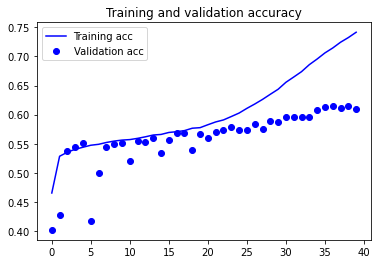

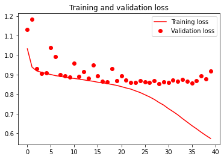

```python
acc = history.history['accuracy']
val_acc = history.history['val_accuracy']
loss = history.history['loss']
val_loss = history.history['val_loss']

epochs = range(len(acc))

plt.plot(epochs, acc, 'b', label='Training acc')
plt.plot(epochs, val_acc, 'bo', label='Validation acc')
plt.title('Training and validation accuracy')
plt.legend()

plt.figure()

plt.plot(epochs, loss, 'r', label='Training loss')
plt.plot(epochs, val_loss, 'ro', label='Validation loss')
plt.title('Training and validation loss')
plt.legend()

plt.show()
```

```python
cnnspec.summary()
```

```python
loss, accuracy = cnnspec.evaluate(test_set)
```

[output not shown]

```python
cnnspec.save('cnnspec_v1.h5')
```

[output not shown]

[output cut: 18 more lines]

[output not shown]

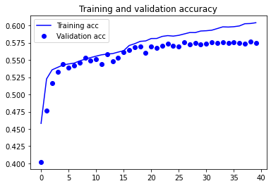

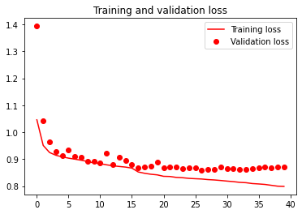

```python
acc = history.history['accuracy']
val_acc = history.history['val_accuracy']
loss = history.history['loss']
val_loss = history.history['val_loss']

epochs = range(len(acc))

plt.plot(epochs, acc, 'b', label='Training acc')
plt.plot(epochs, val_acc, 'bo', label='Validation acc')
plt.title('Training and validation accuracy')
plt.legend()

plt.figure()

plt.plot(epochs, loss, 'r', label='Training loss')
plt.plot(epochs, val_loss, 'ro', label='Validation loss')
plt.title('Training and validation loss')
plt.legend()

plt.show()
```

```python
cnnspec.summary()
```

```python
loss, accuracy = cnnspec.evaluate(test_set)
```

[output not shown]

```python
cnnspec.save('cnnspec_v2.h5')
```

[output not shown]

[output cut: 18 more lines]

[output not shown]

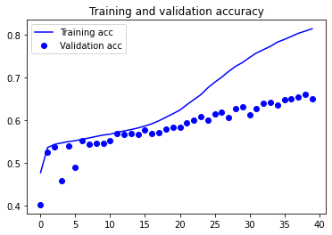

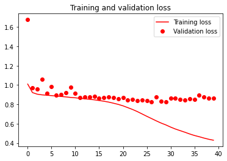

```python
acc = history.history['accuracy']
val_acc = history.history['val_accuracy']
loss = history.history['loss']
val_loss = history.history['val_loss']

epochs = range(len(acc))

plt.plot(epochs, acc, 'b', label='Training acc')
plt.plot(epochs, val_acc, 'bo', label='Validation acc')
plt.title('Training and validation accuracy')
plt.legend()

plt.figure()

plt.plot(epochs, loss, 'r', label='Training loss')
plt.plot(epochs, val_loss, 'ro', label='Validation loss')
plt.title('Training and validation loss')
plt.legend()

plt.show()
```

```python
loss, accuracy = cnnspec.evaluate(test_set)
```

[output not shown]

```python
cnnspec.save('cnnspec_v3.h5')
```

## Conclusion and Findings

Out of the 3 experimental architectures, we found that overfitting was still a problem, although it was best mitigated in "v2". Where the overfitting doesn't start until reaching epoch 20 or so. Even though we were able to attain slightly better results with the newer versions, our loss was consistently flat-lining after x amount of epochs. Because this was a constant throughout our experimentation we might conclude that our model was not learning from our data at all or that the data could possibly be too complex. If the data was to complex we might be required to increase layers and network depth to extract features that are more unique to the 3 classes we have, requiring more training time and resources which would be rather expensive in the long run.

However, working within the constraints of time and resources we tested the majority of potential architectures and frameworks and could not break above 70% accuracy without heavy overfitting/underfitting. The final conclusion we came to is that our original dataset needs to be reworked in a way that is better able to be processed by a neural net. Whether that means a re-balancing, using images in a different color mode or a new type of augmentation technique, it will be reserved for future work.

### Possible Issues:

- Models not learning, only memorizing
- Data problems
  - Unbalanced
  - Too complex for architecture?